# DS152 Tutorial Sheet 5

## Exercise

We will work with the `biopsy` data (you’ve worked with this dataset before). It is a breast cancer database obtained from the University of Wisconsin-Madison Hospital. 699 biopsies of breast tumours were assessed and nine attributes (`V1` - `V9`) were scored on a scale of 1 to 10. The objective is to predict whether a tumour is `benign` (0) or `malignant` (1), based on 5 of the attributes.

Below we have a glimpse of the dataset.

```r
biopsy <- MASS::biopsy
glimpse(biopsy)
```

```
Rows: 699
Columns: 11
$ ID    <chr> "1000025", "1002945", "1015425", "1016277", "1017023", "1017122"…
$ V1    <int> 5, 5, 3, 6, 4, 8, 1, 2, 2, 4, 1, 2, 5, 1, 8, 7, 4, 4, 10, 6, 7, …
$ V2    <int> 1, 4, 1, 8, 1, 10, 1, 1, 1, 2, 1, 1, 3, 1, 7, 4, 1, 1, 7, 1, 3, …
$ V3    <int> 1, 4, 1, 8, 1, 10, 1, 2, 1, 1, 1, 1, 3, 1, 5, 6, 1, 1, 7, 1, 2, …
$ V4    <int> 1, 5, 1, 1, 3, 8, 1, 1, 1, 1, 1, 1, 3, 1, 10, 4, 1, 1, 6, 1, 10,…
$ V5    <int> 2, 7, 2, 3, 2, 7, 2, 2, 2, 2, 1, 2, 2, 2, 7, 6, 2, 2, 4, 2, 5, 6…
$ V6    <int> 1, 10, 2, 4, 1, 10, 10, 1, 1, 1, 1, 1, 3, 3, 9, 1, 1, 1, 10, 1, …
$ V7    <int> 3, 3, 3, 3, 3, 9, 3, 3, 1, 2, 3, 2, 4, 3, 5, 4, 2, 3, 4, 3, 5, 7…
$ V8    <int> 1, 2, 1, 7, 1, 7, 1, 1, 1, 1, 1, 1, 4, 1, 5, 3, 1, 1, 1, 1, 4, 1…
$ V9    <int> 1, 1, 1, 1, 1, 1, 1, 1, 5, 1, 1, 1, 1, 1, 4, 1, 1, 1, 2, 1, 4, 1…
$ class <fct> benign, benign, benign, benign, benign, malignant, benign, benig…
```

We’re going to update the dataset to add a binary (0,1) version of the class variable.

```r
biopsy <- biopsy %>% mutate(class_binary = as.numeric(class == "malignant"))
```

**(a)** Before we begin modelling the data, let’s split the dataset in two: the training and the test set. We will fit the models using the training set, and then validate them using the test set. We will use 60% of the data as the training set, and the remaining 40% as the test set. Set the seed to 103 and replace [A], [B], [C] and [D] in the code below to create these training and test datasets.

```r
library(rsample)
library(rpart)
set.seed(103)
biopsy_split <- initial_split(biopsy, prop = 0.6)
train_biopsy_data <- training(biopsy_split)
test_biopsy_data  <- testing(biopsy_split)
```

**(b)** We will use 2 different machine learning algorithms, namely:

- Method 1: multiple logistic regression
- Method 2: classification tree

We will fit them to the training set and then we will compare how well they perform on the test set.

Replace [A] and [B] in the code below to fit a logistic regression model to the training data using all variables (`V1` to `V5`) as predictors and `class_binary` as the outcome/response. Call the fitted model object `logistic_model`.

```r
logistic_model  <- glm(class_binary ~ V1 + V2 + V3 + V4 + V5, family = binomial, data = train_biopsy_data)
```

**(c)** Now replace [A], [B] and [C] in the code below to fit a classification tree and call it `tree_model` and plot the classification tree.

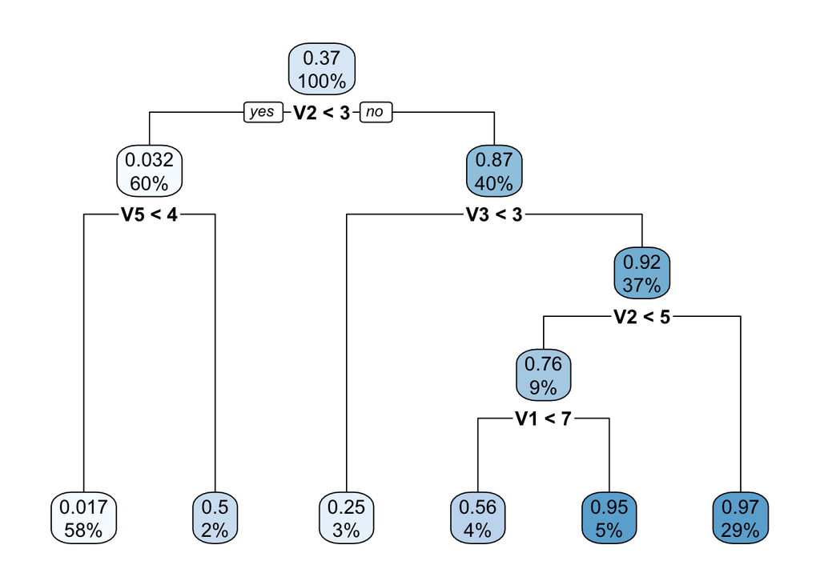

```r
library(rpart)
library(rpart.plot)

tree_model <- rpart(class_binary ~ V1 + V2 + V3 + V4 + V5,data = train_biopsy_data)
rpart.plot(tree_model)
```

**(d)** Now we will use the test set to evaluate the two different methods. Below are the confusion tables for each method, using the test set.

#### Logistic regression model

```
           pred_class1
class       benign malignant
  benign       188         6
  malignant      6        80
```

#### Classification tree model

```
           pred_class2
class       benign malignant
  benign       180        14
  malignant      4        82
```

Calculate the overall accuracy, true positive rate and true negative rate for each method you trained. We take positive to be `malignant`, and negative to be `benign`.

#### logistic model

```r
## accuracy
sum(diag(confusion_logistic))/(sum(confusion_logistic))
```

```
[1] 0.9571429
```

```r
## TPR TP/(TP + FN)
confusion_logistic[2,2]/(sum(confusion_logistic[2,]))
```

```
[1] 0.9302326
```

```r
## TNR TN/(TN + FP)
confusion_logistic[1,1]/(sum(confusion_logistic[1,]))
```

```
[1] 0.9690722
```

#### tree model

```r
## accuracy
sum(diag(confusion_tree))/(sum(confusion_tree))
```

```
[1] 0.9357143
```

```r
## TPR TP/(TP + FN)
confusion_tree[2,2]/(sum(confusion_tree[2,]))
```

```
[1] 0.9534884
```

```r
## TNR TN/(TN + FP)
confusion_tree[1,1]/(sum(confusion_tree[1,]))
```

```
[1] 0.9278351
```

**Note for tutors:** You don’t need to co through all the code for creating the predictions etc here just focus on how to do the calculations from the confusion tables.

5. Now we will use the k-nearest neighbours algorithm on the biopsy data. We will use k = 3 and k = 6 and compare results. The code below fits the models and gives predictions.

```r
library(class)
pred_class_knn3 <- knn(train_biopsy_data %>% select(V1:V5),
                     test_biopsy_data %>% select(V1:V5),
                     cl =   train_biopsy_data %>% pull(class),
                     k = 3)

pred_class_knn6 <- knn(train_biopsy_data %>% select(V1:V5),
                     test_biopsy_data %>% select(V1:V5),
                     cl =   train_biopsy_data %>% pull(class),
                     k = 6)


biopsy_res_knn <- test_biopsy_data %>%
                  mutate(pred_class3 = pred_class_knn3) %>%
                  mutate(pred_class6 = pred_class_knn6)
```

Now we can have a look at the confusion tables:

```r
N <- nrow(biopsy_res_knn)

confusion_mat3 <- table(biopsy_res_knn  %>% select(class, pred_class3))
confusion_mat3
```

```
           pred_class3
class       benign malignant
  benign       187         7
  malignant      4        82
```

```r
confusion_mat6 <- table(biopsy_res_knn  %>% select(class, pred_class6))
confusion_mat6
```

```
           pred_class6
class       benign malignant
  benign       186         8
  malignant      5        81
```

**Note for tutors:** Talk through the code here for part (e) as knn is a little different to the other methods in how the code is formatted.

Then calculate the overall accuracy, true positive rate and true negative rate for each method you trained. We take positive to be `malignant`, and negative to be `benign`.

#### for k = 3

```r
## accuracy
sum(diag(confusion_mat3))/(sum(confusion_mat3))
```

```
[1] 0.9607143
```

```r
## TPR TP/(TP + FN)
confusion_mat3[2,2]/(sum(confusion_mat3[2,]))
```

```
[1] 0.9534884
```

```r
## TNR TN/(TN + FP)
confusion_mat3[1,1]/(sum(confusion_mat3[1,]))
```

```
[1] 0.9639175
```

#### for k = 6

```r
## accuracy
sum(diag(confusion_mat6))/(sum(confusion_mat6))
```

```
[1] 0.9535714
```

```r
## TPR TP/(TP + FN)
confusion_mat6[2,2]/(sum(confusion_mat6[2,]))
```

```
[1] 0.9418605
```

```r
## TNR TN/(TN + FP)
confusion_mat6[1,1]/(sum(confusion_mat6[1,]))
```

```
[1] 0.9587629
```